# Homework 1

Austin Harnsberger

1/7/2015

**Exercise 1**

```r
v9 <- sample(c(1:6), 10, replace=TRUE, prob=c(.167,.167,.167,.167,.167,.167)); v9
```

```
##  [1] 4 5 6 4 5 1 2 1 6 3
```

**Exercise 2**

```r
integrate(dnorm, -1, 1)
```

```
## 0.6826895 with absolute error < 7.6e-15
```

```r
integrate(dnorm, -3, 0)
```

```
## 0.4986501 with absolute error < 5.5e-15
```

```r
integrate(dnorm, -2, 2)
```

```
## 0.9544997 with absolute error < 1.8e-11
```

**Exercise 3**

```r
# integrate(dnorm(x, 100, 15), 100, 130)
mynormalFn = function(x) {return(dnorm(x, 100, 15))}
mynormalFn(5)
```

```
## [1] 5.185632e-11
```

```r
integrate(mynormalFn, 100, 130)
```

```
## 0.4772499 with absolute error < 5.3e-15
```

**Exercise 4**

```r
qexp(.5, .0001)
```

```
## [1] 6931.472
```

```r
pexp(qexp(.5, .0001),0,200)
```

```
## [1] 0
```

**Exercise 6**

```r
ss = read.csv("http://www.calvin.edu/~scofield/data/csv/studentSurveyS04.csv")
v2all <- ss[,17]
v2 <- sample(v2all, 10, replace=TRUE)
v2rural <- v2[1:10] == "Rural"
v2suburban <- v2[1:10] == "Suburban"
v2urban <- v2[1:10] =="Urban"
```

**Exercise 7**

```r
ss = read.csv("http://www.calvin.edu/~scofield/data/csv/studentSurveyS04.csv")
ss$momhandedness # produces vector containing momhandedness responses
```

```
##   [1] L R R R R R R R R R R R R R R R R R R R R R R R R R R L R R R R R R R
##  [36] R L R R L R R R R R R R R L R R R R L R R R R R R R R R R R R R R R R
##  [71] R R R R L R R R R R R R R R R R R R R R R R R R R R R R R R R R R R R
## [106] R R R R R R R R R R R R R R R R R R R R R R R R R R R R R R R R R R R
## [141] R R R R R R R R R R R R R R R R L R R R R R R R R L R R R R   R L R R
## [176] R R L R R R R R R R L R R R R L R R R R R R R R R R R R R R R R R R R
## [211] R R R L R R R R R R R R R R R R R R R R R R R R R R R L R R R R R R R
## [246] R R R R R R R R R R R R R R R R R R R R R R R R R R   L R R R R R R R
## Levels:  L R
```

```r
xtabs(~ momhandedness, data=ss) # Note the need for "cleaning" the data
```

```
## momhandedness
##       L   R
##   2  16 262
```

```r
twiceCleanedSS = droplevels(subset(ss, momhandedness!=""))
xtabs(~ momhandedness, data=twiceCleanedSS)
```

```
## momhandedness
##   L   R
##  16 262
```

```r
prop.table(xtabs(~ momhandedness, data=twiceCleanedSS))
```

```
## momhandedness
##          L          R
## 0.05755396 0.94244604
```

**Exercise 8** Thinking of momhandedness as an explanatory variable, the most useful commands to use would be > prop.table(xtabs(~selfhandedness + momhandedness, data=twiceCleanedSS), margin=1) > prop.table(xtabs(~selfhandedness + momhandedness, data=twiceCleanedSS), margin=2)

These would be most useful because they give percentages for the handedness of both the mother and child and provide a side by side comparison.

**Exercise 10**

```r
require(lattice)
ss = read.csv("http://www.calvin.edu/~scofield/data/csv/studentSurveyS04.csv")
xtabs(~cds, data=ss)
```

```
## cds
##   0   1   2   3   4   5   6   7   8  10  11  12  13  14  15  17  18  20
##   1   1   1   6   1   2   1   1   3  12   1   1   2   3  15   2   2  21
##  21  22  23  24  25  26  29  30  32  35  36  37  39  40  41  45  46  47
##   1   3   2   4  12   1   3  31   2   5   1   3   1  19   1   6   1   1
##  50  52  53  54  55  57  60  61  64  65  67  70  75  80  90  94 100 101
##  20   2   1   1   2   1  11   1   1   6   1   1   6   5   3   1  13   1
## 103 110 112 115 120 130 135 145 150 170 200 240 250 601
##   1   2   2   1   1   2   1   1   7   1   3   1   2   1
```

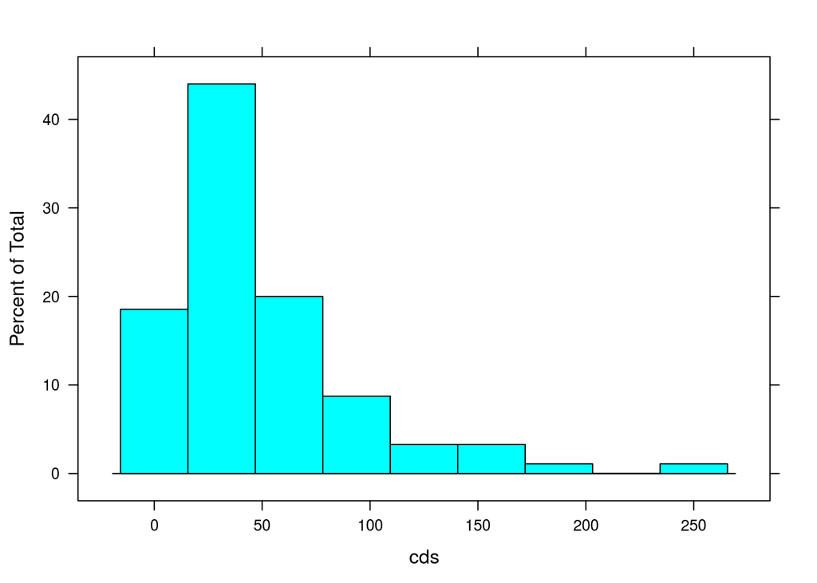

```r
v4 = droplevels(subset(ss, cds < 300))
histogram(~cds, data=v4, type="percent")
```

**Exercise 11** We would expect to see an equal amount of cds owned by both males and females, this is generally what we see here. Here, there is a fair similarity between genders.

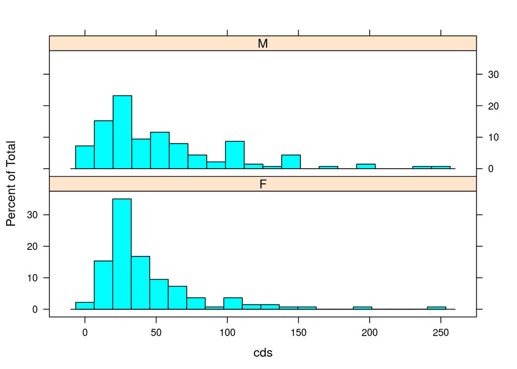

```r
ss = read.csv("http://www.calvin.edu/~scofield/data/csv/studentSurveyS04.csv")
v4 = droplevels(subset(ss, cds < 300))
histogram(~cds | gender, data=v4, n=20, layout=c(1,2), type="percent")
```

**Exercise 12** Yes, there is a discrepency because of the living conditions. Kids living in rural areas are further away from store that sell cds than suburban kids, and likewise with urban kids.

```r
ss = read.csv("http://www.calvin.edu/~scofield/data/csv/studentSurveyS04.csv")
xtabs(~cds, data=ss)
```

```
## cds
##   0   1   2   3   4   5   6   7   8  10  11  12  13  14  15  17  18  20
##   1   1   1   6   1   2   1   1   3  12   1   1   2   3  15   2   2  21
##  21  22  23  24  25  26  29  30  32  35  36  37  39  40  41  45  46  47
##   1   3   2   4  12   1   3  31   2   5   1   3   1  19   1   6   1   1
##  50  52  53  54  55  57  60  61  64  65  67  70  75  80  90  94 100 101
##  20   2   1   1   2   1  11   1   1   6   1   1   6   5   3   1  13   1
## 103 110 112 115 120 130 135 145 150 170 200 240 250 601
##   1   2   2   1   1   2   1   1   7   1   3   1   2   1
```

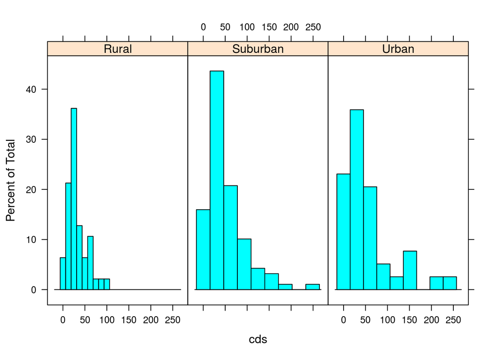

```r
v4 = droplevels(subset(ss, cds < 300))
v5 = droplevels(subset(v4, region!=""))
histogram(~cds | region, data=v5, type="percent")
```

**Exercise 13**

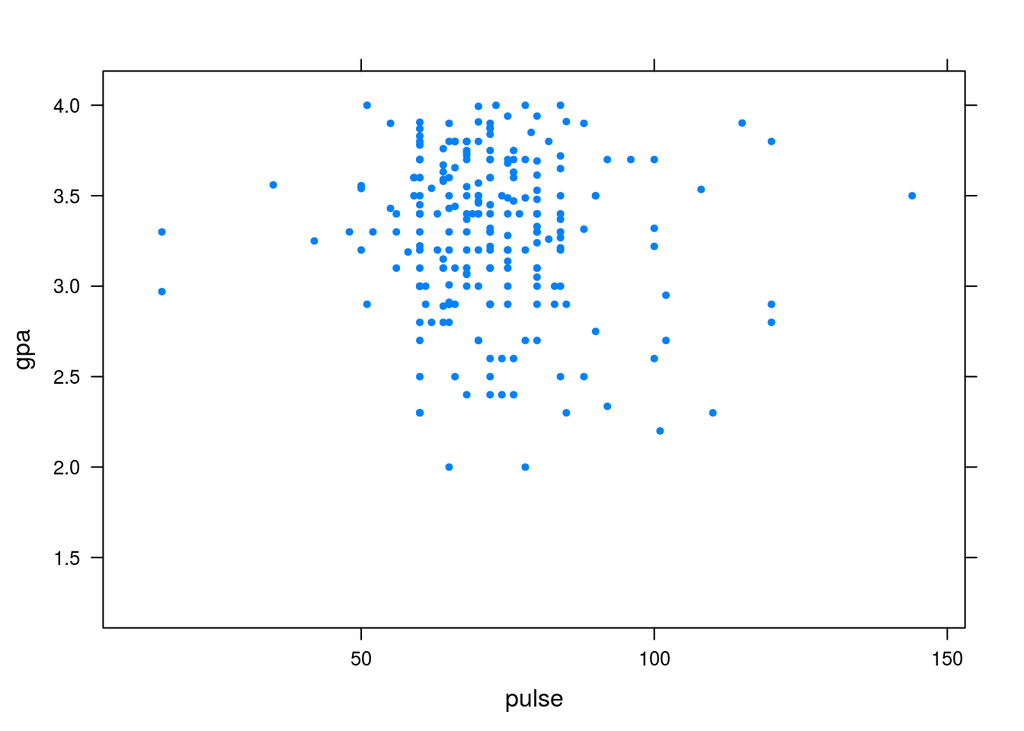

```r
xyplot(gpa ~ pulse, data=ss, pch=19, cex=.5)
```

I am not convinced that a correlation exists between pulse and gpa. There are too varied of responses for me to be satisfied with that conclusion.

**Write-up to Video Question** The problem I found most interesting from the video was the interpretation of the four different slides using various infared imaging and interpreting the data to create a representation of what the actual field looks like. I am extremely curious how to draw the separations and classify what is what on a map from these infared scans. The variables I would use are the imaging colors, shades, and shapes from the infared imaging.